# 序論

経済学各論(機械学習)

川田恵介

keisukekawata@iss.u-tokyo.ac.jp

- 講義資料: https://github.com/tetokawata/UnderGradEconML
1. データ分析周りのキーワード
2. “事例”から学ぶ難しさ
   - 機械学習でも、インタビュー調査でも、歴史分析でも直面
3. 適切に単純化されたモデルによる解決
   - 機械学習・計量経済学・統計学のきも
4. 講義の概要
5. 次回への準備

# データ分析

- 不完全な事例集（経験、歴史、データ等）から人間が学ぶ方法
  - 経済学では、「“意思決定”に生かす知見」を伝統的に重視
- データ分析への注目はますます高まる
  - [AI人材](https://tameni.mynavi.jp/market/3929/)
  - リスキリングにおける人気項目
- 学際的発展
  - 経済学 🤝 経営学 🤝 金融(工)学 🤝 生物・医学 🤝 政治学 🤝 社会学 🤝 統計学 🤝 計算機科学
  - 大学 🤝 企業 🤝 公的機関

## 機械学習

- “統計学” (計量経済学の土台) とは異なるルーツ(AIの開発)を有するデータ分析方法
  - 今では中核技術
- 様々な”バズ”技術に活用
  - [ChatGPT](https://utelecon.adm.u-tokyo.ac.jp/docs/20230403-generative-ai), AlphaGoなどなど

## 経済学部生と機械学習

- 志望キャリアをと会わず、経済学部生が知っておくべき教養となりつつある
  - データ分析自体はもちろん、正しく分析結果を活用する・“規制”する、ためにも重要
- [日本企業内経済学者](https://www.cyberagent.co.jp/way/list/detail/id=26613)
- [日本経済センター: 研修制度](https://www.jcer.or.jp/human-resource)

## 機械学習 + (計量)経済学

- 伝統的な計量経済学との融合が進む
- 特に重要なフィールドの一つ
- 例: マイクロソフトが進めるプロジェクト
  - [EconML](https://www.microsoft.com/en-us/research/project/econml/)

## イメージ図：ゴール像

[interactive chart not shown]

## 例: 需要予測

- 過去の販売事例から、店舗レベルでの需要予測の精度が改善
  - 意思決定者が、物流・発注システムの改革も行うことで、食品破棄・売り逃しを減らせる
- 個人レベルでの予測精度が”大幅”改善
  - 意思決定者は、まったく新しい通販サービスの提供できる?
  - 注文を受ける”前”に、予測された商品を発送、キャンセルしなければ料金を支払う (“注文 $\rightarrow$ 発注”から “発注 $\rightarrow$ 注文”へ)
- 予測マシンの世紀 AIが駆動する新たな経済

## 他のワード

- 強化学習、深層学習 (Deep Learning), Generative Model $=$ 機械学習の一手法
  - 本講義では教師付き学習を学び、その中で深層学習,Generative Modeにも触れる
- ビッグデータ：”大きなデータ”
  - 元の定義は一つのコンピュータでは処理できないほど大きなデータ
- データサイエンス：厳密な定義はない
- [ChatGPT](https://www.gizmodo.jp/2023/01/chat-gpt-openai-ai-finance-ai-everything-we-know.html) 教師付き学習や強化学習を組みあせて、複雑な予測結果を表示 (Generative model)

# 事例から学ぶ技術

- 他者の事例・自身の経験・歴史を意思決定にどう生かすか？
  - 普遍的な課題
- （例）経験豊富な指導者が
  - 「練習中の水分補給を禁止」
  - 「筋肉を増やすために、超長距離遠泳を指示」
- アドバイスを聞くべきなのか、それとも”老害”なのか？
- 意思決定の際に参照すべき事例はどれか、“偶然生じた例外的”事例を間違えて採用してないか？
  - 「データから観察できない要素が大量に存在する」、社会科学・実務において深刻な課題

## イメージ図

[interactive chart not shown]

## 例: 練馬1Lの取引価格は？

| 立地 | 部屋 | 取引価格（100万円） |
| --- | --- | --- |
| 練馬 | 1DL | 100 |
| 板橋 | 1L | 10 |
| 板橋 | 1DL | 8 |
| 板橋 | 1DL | 12 |
| 板橋 | 1DL | 20 |
| 板橋 | 1DL | 30 |

## 課題

- “全く同じ”事例が存在しない・極めて少数しか存在しない
  - なんとなくよく似た事例を参考にする？
- 一見同じに見える事例においても、“矛盾”が存在
  - なんとなく多数派の事例を採用？
- 例外的に見える事例が存在
  - なんとなく削除する？
- 事例集のもつ”不完全性”にどのように対応するか？
  - 社会・経済データへの応用において普遍的な問題

## データ分析

- ”大規模”な事例集 ( $=$ データ）から、検証可能な形で学ぶ方法
  - 業務の電子化により、容易に蓄積可能
  - ただし課題はそのまま
  - 多くの解決策が提案
- PCの性能改善により、さまざまな分析手法が実行可能
  - “誰にでも”使いやすいプログラムの開発
  - 無料のRやPythonに多く実装

## 現状の問題点

- 事例集が巨大化: より多くの事例について、より多くの情報を取得できる
- 以前として、“誤解”が多い
  - 「ボタンの掛け違い」
- 高校までの授業では、あまり重点を置かれていない”枠組み”への理解が必要
  - 人(分析者)によって結果が違う
  - 確率的事象

## “合意”の枠組み

- 最終的な目標は、 “有益かつ、合意できる示唆を得る”
- “綺麗”な世界の現象については、厳密な合意が可能
  - 理科室の実験では、同じ結果を得られる
- 現実の世界では、厳密な合意は不可能
  - 同じやり方で収集したデータを、同じやり方で分析したとしても、結果は人によって異なる
  - データが異なるため

# 機械学習

- 統計学/計量経済学とは異なるルーツ(**AI**の開発)をもつデータ分析手法
  - 教師付き学習、教師なし学習、強化学習、等々
- 計量経済学とよく似た問題意識

  - 方言が大きく異なる
- 発展するにつれて、当初の目的を超えた価値を持つ
  - 特に変数が多い/複雑なデータ（Rich data）を用いた、予測問題で威力を発揮
  - 計量経済学や医療・生物統計との融合により、因果効果や格差推定においても有益

## 予測問題とは

- 事前に観察できる情報 $X$ から、 $Y$ を予測する
  - 中古車買取マニュアル作り：ある車 $X$ がいくら $=Y$ で再販できる？
  - 動画のsuggestionシステム：あるユーザー $=X$ がある動画をどのように”評価” $=Y$ するか？
  - 退学、留年する可能性がある学生へのケア：ある学生が退学してしまう確率は？
  - ”マクロ”政策：将来の人口、景気は?
- 機械学習が大きな比較優位をもつ

## 学習とは

- 煩雑な経験(ヒアリング結果、歴史、個人的経験など) -> 学習 -> 知見
  - 知見の一つ = 予測

## 素朴な方法

- よくある主張
  - “「モデルや理論」を用いずに、現実の事例をしっかりみるべき”
- 最もnaiveな学習法 $=$ 事例の丸暗記 (learning by memorization)
  - 予測したい対象と同じ事例を思い出して、その結果を予測値とする
  - 全く同じ事例がなければ、“最も近い”事例を参照
  - 予測したい事象が単純かつデータが十分あれば、機能しうる

## 丸暗記法が有効なケース

- 「限られた情報から整合的な結果」を生み出すように”設計”されているのであれば有効
- 例
  - 判例
  - 同じ企業内の賃金
- 就活?、チャットでの質問？

## 丸暗記のジレンマ

- 社会における事象 $=$ 大量の要因が影響を与えている
  - データから観察できないものが多数
  - 本来的には、同じ事象は”存在しない”
- 多くの属性を活用しようとすると、事例数が減少する

## 例

- 38歳香川県出身男性の化粧水への需要を予測したい
  - 事例の中に川田が含まれている $\rightarrow$ 高い需要を予測
- 事例数が増えると、同じ属性の事例が増え、川田の影響は薄まるが
- 年齢・性別・出身地以外にも、予測において重要な属性もありそう
  - 活用する変数を増やす(+ 学歴 + 職業 + 年収 +…)と、同一事例が減り、また川田のみになる

## 丸暗記

[interactive chart not shown]

## 丸暗記の限界

- 丸暗記法がうまくいく前提: 化粧水の消費量を決める重要な要因が全て事例集に記録され、かつ十分な事例数がある
  - ほとんどの応用事例で不可能
- 例: 一卵性の双子
  - 生まれた時点では”ほとんど同じ”属性を持つが、、、

## 単純化 & 一般化

- 過去の事例がないケースについても、予測する必要がある
  - 一般化 (generalization)
- 適切な単純化が必要
  - 観察できない属性が大きく偏っている事例の影響を抑えるため
  - 人間も(無意識的)に行っている

## 近似モデル

- 近似モデルをデータから推定
  - 近似モデル：複雑な現実を適切に単純化したモデル
- [フェルミ推定](https://www.in-fra.jp/long-internships/articles/647)

**Important**

- *Truth is much too complicated to allow anything but approximations*
  - [(John von Neumann)](https://ja.wikipedia.org/wiki/%E3%82%B8%E3%83%A7%E3%83%B3%E3%83%BB%E3%83%95%E3%82%A9%E3%83%B3%E3%83%BB%E3%83%8E%E3%82%A4%E3%83%9E%E3%83%B3)

## トレードオフ

- “現実は複雑なのだから、複雑なモデルを用いるべきでは?”
  - 複雑な現実を捉えられる
  - データから推定することが難しくなる

# 講義概要

- 前提知識: 四則演算、基礎的な統計知識（平均や分散など）
- 講義資料: 講義スライド、実習用データ
  - Github repository ([リンク](https://github.com/tetokawata/UnderGradEconML))) からダウンロード可能
  - Rの実装については、Github repository([リンク](https://github.com/tetokawata/R_JPN)) も参照
- 実習環境: [**Posit cloud**](https://rstudio.cloud/)
  - インターネット上で作業できる (自宅からでも)
  - 関心に応じて、R と Rstudioを自身のPCにインストール

## 成績評価

- レポート(100%)
  - 授業期間中に3回実施（１）各手法が正しく使えているか、（２）結果を正しく解釈できているか

## ゴール

- 機械学習（教師付き学習）のコンセプトを理解し、自身でデータに応用できる
- レポートを通じて、[国土交通省](https://www.land.mlit.go.jp/webland/servlet/MainServlet)が提供するデータを用いて、以下を実装するプログラム作成
  - 中古マンション取引価格を予測するモデル
  - 中古マンションを改装する平均効果の推定
  - 改装の効果を予測するモデル
- “履歴書”に、“機械学習の分析用コードを作成し、実際のデータ分析”を行ったことがある、と書けるようにする。

## 無料ソフトの利用

- RないしPythonを強く推奨
  - 企業、大学、公的研究機関の研究者が幅広く利用
- 本講義ではRを使用
  - クラウド上の開発環境であるRcloudを併用
  - ネットにさえ繋がれば、異なるPCで作業できる

# 例

- 講義で用いるデータを使って、取引価格の予測モデルを構築

## 例: サンプルサイズ

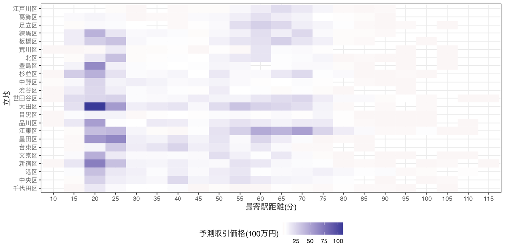

## 例: Learning by memoraization

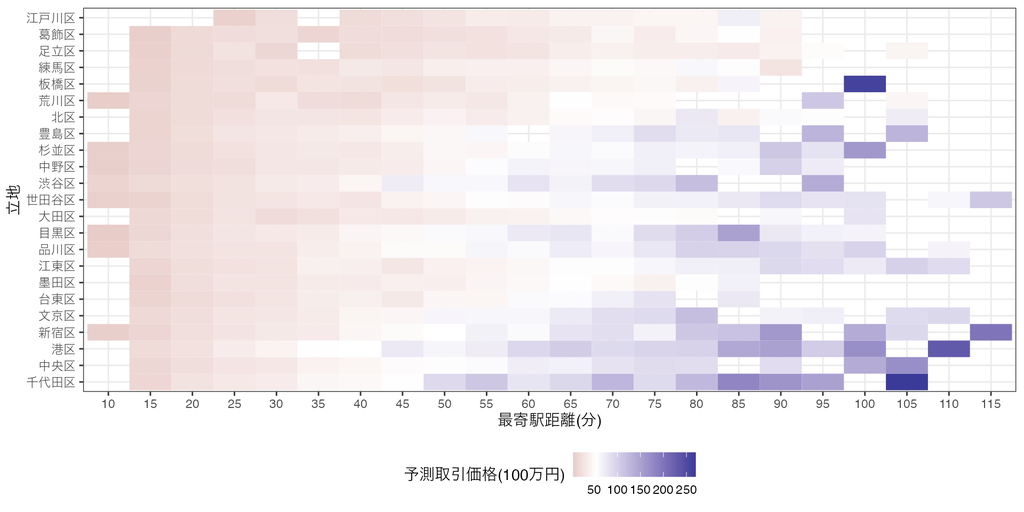

## 例: Learning by memoraizationもどき

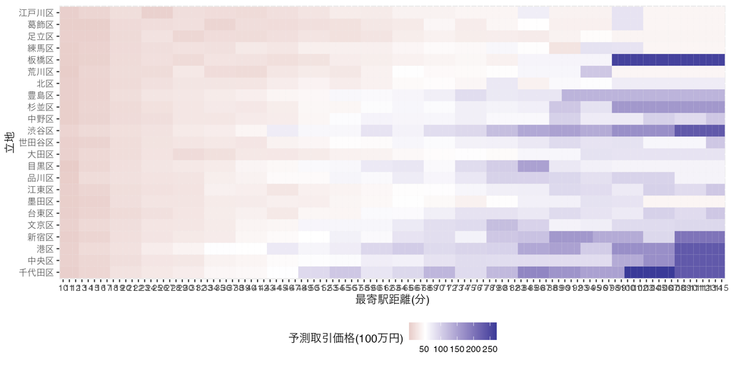

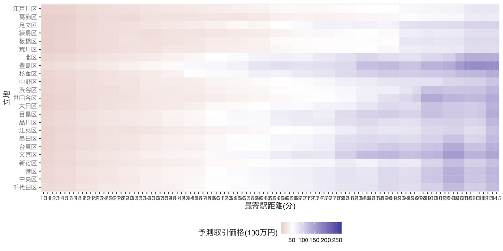

## ICE: OLS

```
y not passed, so range_y is range of ice curves and sd_y is sd of predictions on real observations
```

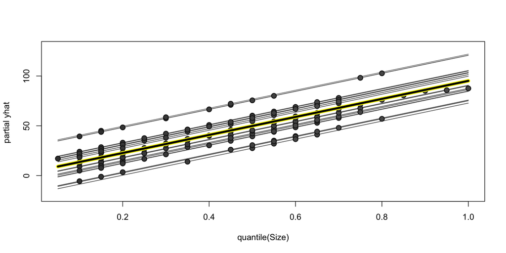

## ICE: SuperLearner

```
y not passed, so range_y is range of ice curves and sd_y is sd of predictions on real observations
```

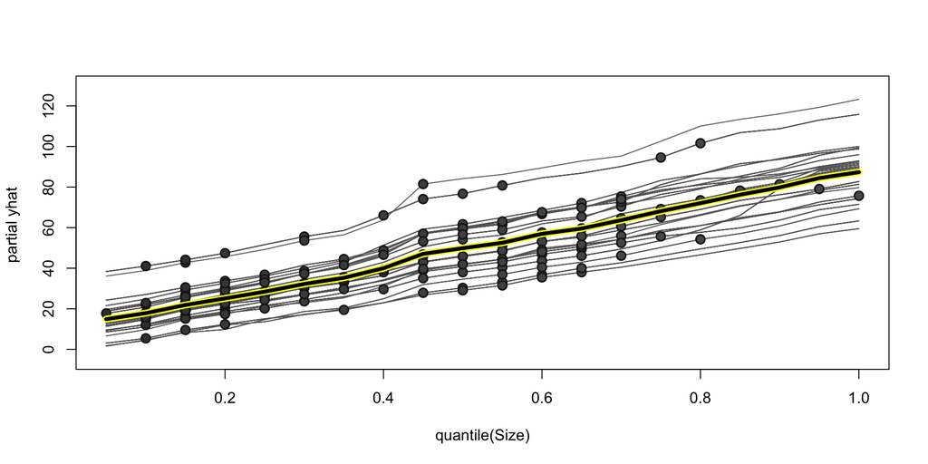

## ICE: 丸暗記

```
y not passed, so range_y is range of ice curves and sd_y is sd of predictions on real observations
```

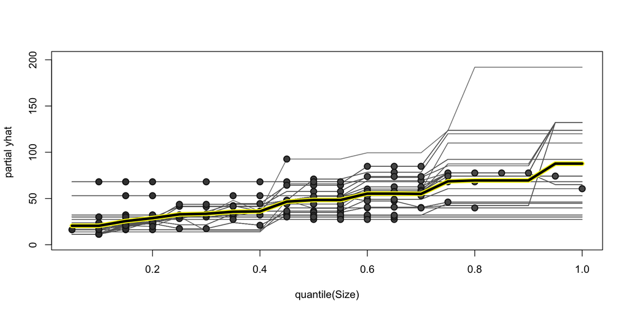

# 次回までに

- Positcloudの設定 ([Youtubeへのリンク](https://youtu.be/yF6NxxvpzjE))
  - 時間がある人は本日中に